# Tidy Tuesday : Merging Datasets

In data science, a very common challenge that you will encounter is the problem of *merging datasets*. Two datasets can be merged when they share one or more columns in common. Let’s take a look at the Tidy Tuesday dataset from this week, and see what we need to do in order to create visualizations of the dataset.

```r
library(tidyverse)

broadband <- readr::read_csv('https://raw.githubusercontent.com/rfordatascience/tidytuesday/master/data/2021/2021-05-11/broadband.csv')

broadband %>%
  head()
```

```
## # A tibble: 6 x 5
##   ST    `COUNTY ID` `COUNTY NAME`  `BROADBAND AVAILABILITY PER… `BROADBAND USAG…
##   <chr>       <dbl> <chr>          <chr>                        <chr>
## 1 AL           1001 Autauga County 0.81                         0.28
## 2 AL           1003 Baldwin County 0.88                         0.30
## 3 AL           1005 Barbour County 0.59                         0.18
## 4 AL           1007 Bibb County    0.29                         0.07
## 5 AL           1009 Blount County  0.69                         0.09
## 6 AL           1011 Bullock County 0.06                         0.05
```

It looks like we have variables `BROADBAND AVAILABILITY PER FCC` and `BROADBAND USAGE` that are associated with each *county* in the United States. This means that we will need map data at the county level. Let’s use the `urbnmapr` package. First, run

```r
#If you don't already have devtools installed, run the line below
#install.packages("devtools")

devtools::install_github("UrbanInstitute/urbnmapr")
```

We now have access to a dataset of county level data:

```r
library(urbnmapr)

county <- urbnmapr::counties

county %>%
  head()
```

```
## # A tibble: 6 x 12
##    long   lat order hole  piece group   county_fips state_abbv state_fips
##   <dbl> <dbl> <int> <lgl> <fct> <fct>   <chr>       <chr>      <chr>
## 1 -86.9  32.7     1 FALSE 1     01001.1 01001       AL         01
## 2 -86.8  32.7     2 FALSE 1     01001.1 01001       AL         01
## 3 -86.7  32.7     3 FALSE 1     01001.1 01001       AL         01
## 4 -86.7  32.7     4 FALSE 1     01001.1 01001       AL         01
## 5 -86.4  32.7     5 FALSE 1     01001.1 01001       AL         01
## 6 -86.4  32.4     6 FALSE 1     01001.1 01001       AL         01
## # … with 3 more variables: county_name <chr>, fips_class <chr>,
## #   state_name <chr>
```

Here is where our merging problem comes up- we need to add the `BROADBAND AVAILABILITY PER FCC` and `BROADBAND USAGE` variables to the `county` dataset. There are a few different ways that this merge can be made- `full_join`, `left_join`, `right_join`, and `anti_join`. The word infront of “join” refers to the dataset which keeps all of its values. `full_join` keeps all of the values from each dataset, filling in `NA` for values that don’t appear in the other dataset. `left_join` and `right_join` keep all values from the dataset on the left and right, respectively, and `anti_join` gives all of the values that weren’t matched in the merge. The syntax works as follows:

```r
left_dataset %>%
  full_join(right_dataset, by = column_in_common)
```

If the columns of the datasets don’t have the same name, this is not a big deal. Use the syntax `by = c("left_column_name" = "right_column_name")`. In our case, it is natural to want to merge on the county names, which we do below. I am using a `left_join` because I want to preserve all of the values from the map data.

```r
county %>%
  left_join(broadband, by = c("county_name" = "COUNTY NAME")) %>%
  head()
```

```
## # A tibble: 6 x 16
##    long   lat order hole  piece group   county_fips state_abbv state_fips
##   <dbl> <dbl> <int> <lgl> <fct> <fct>   <chr>       <chr>      <chr>
## 1 -86.9  32.7     1 FALSE 1     01001.1 01001       AL         01
## 2 -86.8  32.7     2 FALSE 1     01001.1 01001       AL         01
## 3 -86.7  32.7     3 FALSE 1     01001.1 01001       AL         01
## 4 -86.7  32.7     4 FALSE 1     01001.1 01001       AL         01
## 5 -86.4  32.7     5 FALSE 1     01001.1 01001       AL         01
## 6 -86.4  32.4     6 FALSE 1     01001.1 01001       AL         01
## # … with 7 more variables: county_name <chr>, fips_class <chr>,
## #   state_name <chr>, ST <chr>, COUNTY ID <dbl>,
## #   BROADBAND AVAILABILITY PER FCC <chr>, BROADBAND USAGE <chr>
```

Great! It looks like the two columns from the `broadband` dataset have been added. Before we keep going, I want to give you a pro tip- **always check whether values have been excluded because of name mismatches**. Did that happen here? Let’s use the `anti_join` function to check. I am using the `select()` function to restrict the output the county names and state abbreviations, and then the `distinct()` function to take out duplicates.

```r
county %>%
  anti_join(broadband, by = c("county_name" = "COUNTY NAME")) %>%
  select(county_name, state_abbv) %>%
  distinct()
```

```
## # A tibble: 2 x 2
##   county_name          state_abbv
##   <chr>                <chr>
## 1 La Salle Parish      LA
## 2 Oglala Lakota County SD
```

We can see that there are two counties which have been excluded- `La Salle Parish` and `Oglala Lakota County`. This means that these counties do not occur in both datasets, or that there is a mismatch in the names of these counties across the datasets. Let’s look at what is happening:

```r
broadband %>%
  filter(ST == "SD") %>%
  select(`COUNTY NAME`) %>%
  pull() %>%
  unique()
```

```
##  [1] "Aurora County"      "Beadle County"      "Bennett County"
##  [4] "Bon Homme County"   "Brookings County"   "Brown County"
##  [7] "Brule County"       "Buffalo County"     "Butte County"
## [10] "Campbell County"    "Charles Mix County" "Clark County"
## [13] "Clay County"        "Codington County"   "Corson County"
## [16] "Custer County"      "Davison County"     "Day County"
## [19] "Deuel County"       "Dewey County"       "Douglas County"
## [22] "Edmunds County"     "Fall River County"  "Faulk County"
## [25] "Grant County"       "Gregory County"     "Haakon County"
## [28] "Hamlin County"      "Hand County"        "Hanson County"
## [31] "Harding County"     "Hughes County"      "Hutchinson County"
## [34] "Hyde County"        "Jackson County"     "Jerauld County"
## [37] "Jones County"       "Kingsbury County"   "Lake County"
## [40] "Lawrence County"    "Lincoln County"     "Lyman County"
## [43] "McCook County"      "McPherson County"   "Marshall County"
## [46] "Meade County"       "Mellette County"    "Miner County"
## [49] "Minnehaha County"   "Moody County"       "Pennington County"
## [52] "Perkins County"     "Potter County"      "Roberts County"
## [55] "Sanborn County"     "Oglala County"      "Spink County"
## [58] "Stanley County"     "Sully County"       "Todd County"
## [61] "Tripp County"       "Turner County"      "Union County"
## [64] "Walworth County"    "Yankton County"     "Ziebach County"
```

Okay- it looks like `Oglala Lakota County` is named `Oglala County` in the `broadband` dataset.

```r
broadband %>%
  filter(ST == "LA") %>%
  select(`COUNTY NAME`) %>%
  pull() %>%
  unique()
```

```
##  [1] "Acadia Parish"               "Allen Parish"
##  [3] "Ascension Parish"            "Assumption Parish"
##  [5] "Avoyelles Parish"            "Beauregard Parish"
##  [7] "Bienville Parish"            "Bossier Parish"
##  [9] "Caddo Parish"                "Calcasieu Parish"
## [11] "Caldwell Parish"             "Cameron Parish"
## [13] "Catahoula Parish"            "Claiborne Parish"
## [15] "Concordia Parish"            "De Soto Parish"
## [17] "East Baton Rouge Parish"     "East Carroll Parish"
## [19] "East Feliciana Parish"       "Evangeline Parish"
## [21] "Franklin Parish"             "Grant Parish"
## [23] "Iberia Parish"               "Iberville Parish"
## [25] "Jackson Parish"              "Jefferson Parish"
## [27] "Jefferson Davis Parish"      "Lafayette Parish"
## [29] "Lafourche Parish"            "LaSalle Parish"
```

[output cut: 17 more lines]

We see that the `La Salle Parish` is named `LaSalle Parish` in the `broadband` dataset. We will need to fix these problems manually. We can use `mutate()` and `gsub()` to search through the `county_name` column and replace the names that we want to adjust. Recall that `gsub()` searches through a string, and replaces any matches with the second argument provided. Using the `anti_join` function, we can check that everything is fixed:

```r
county %>%
  mutate(county_name = gsub("Oglala Lakota County","Oglala County", county_name),
         county_name = gsub("La Salle Parish","LaSalle Parish", county_name)
         ) %>%
  anti_join(broadband, by = c("county_name" = "COUNTY NAME")) %>%
  select(county_name, state_abbv) %>%
  distinct()
```

```
## # A tibble: 0 x 2
## # … with 2 variables: county_name <chr>, state_abbv <chr>
```

Great- it looks like we don’t have any values that have been dropped. Now, we are ready to use the data to create a choropleth map, like we looked at in a previous Tidy Tuesday document. Right now, `BROADBAND AVAILABILITY PER FCC` and `BROADBAND USAGE` are categorical variables- we should treat them as being numerical. Again, we can use the `mutate()` function to do this.

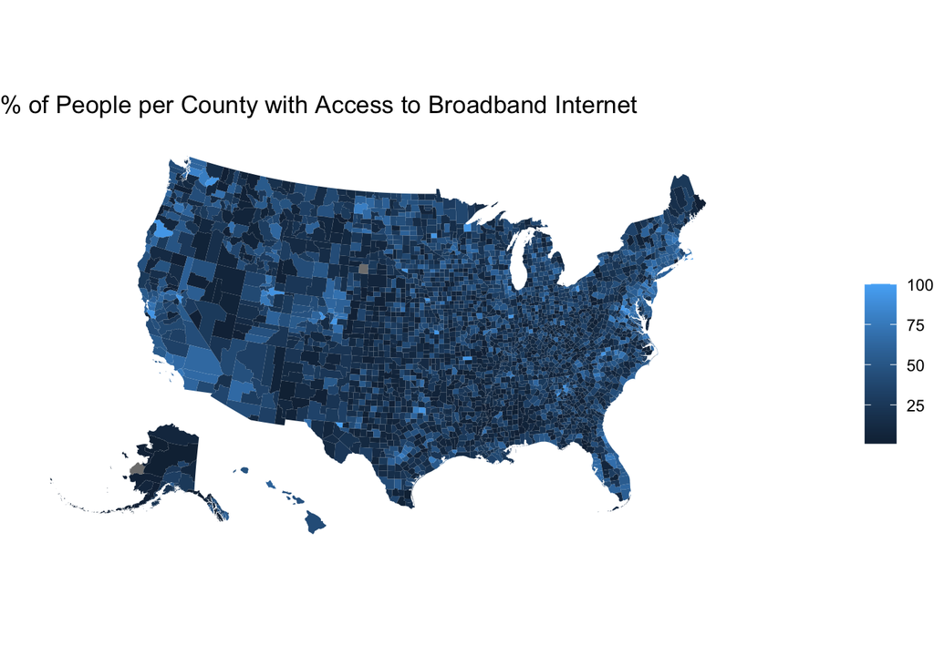

```r
county %>%
  mutate(county_name = gsub("Oglala Lakota County","Oglala County", county_name),
         county_name = gsub("La Salle Parish","LaSalle Parish", county_name)
         ) %>%
  left_join(broadband, by = c("county_name" = "COUNTY NAME")) %>%
  mutate(`BROADBAND USAGE` = 100*as.numeric(na_if(`BROADBAND USAGE`, "-"))) %>%
  ggplot(aes(long,lat, group = group, fill = `BROADBAND USAGE`)) +
  #This makes the borders of the counties transparent
  geom_polygon(color = NA) +
  #This controls the map projection and the bounds for the map
  coord_map(projection = "albers", lat0 = 39, lat1 = 45) +
  labs(x = "Longitude", y = "Latitude", fill = " ") +
  #theme_void makes it so no grid lines or tick marks are shown. We don't want these because we moved Alaska and Hawaii.
  theme_void() +
  ggtitle("% of People per County with Access to Broadband Internet")
```

This map might benefit from binning the numerical variables.

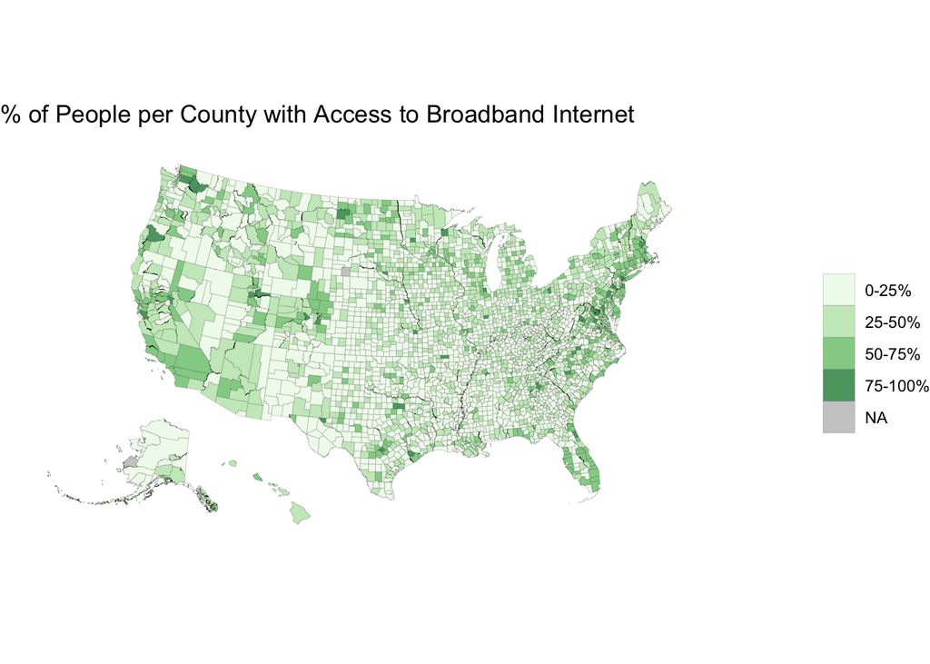

```r
county %>%
  mutate(county_name = gsub("Oglala Lakota County","Oglala County", county_name),
         county_name = gsub("La Salle Parish","LaSalle Parish", county_name)
         ) %>%
  left_join(broadband, by = c("county_name" = "COUNTY NAME")) %>%
  mutate(`BROADBAND USAGE` = 100*as.numeric(na_if(`BROADBAND USAGE`, "-")),
         `BROADBAND USAGE` = cut(`BROADBAND USAGE`, breaks = c(0,25,50,75,100))) %>%
  ggplot(aes(long,lat, group = group, fill = `BROADBAND USAGE`)) +
  geom_polygon(color = "black", size = 0.03, alpha = 0.8) +
  coord_map(projection = "albers", lat0 = 39, lat1 = 45) +
  scale_fill_brewer(palette = "Greens", na.value = "gray", labels = c("0-25%","25-50%","50-75%","75-100%")) +
  labs(fill = NULL) +
  theme_void() +
  ggtitle("% of People per County with Access to Broadband Internet")
```